# STIMA DEI DECESSI DA COVID-19 IN EMILIA-ROMAGNA

$$\\$$

Lavoro a cura di: Alessandro Fossati (mat.819499) Luca Pretini (mat.864014)

$$\\$$

Lo scopo della analisi è quello di stimare i decessi totali da COVID-19 (non solo i casi accertati dalla Protezione Civile) nella regione Emilia-Romagna nel mese di Marzo. Scegliamo questa regione in quanto la copertura dei dati ISTAT risulta soddisfacente a differenza della copertura per la maggior parte delle regioni italiane.

```r
#import dei dati e delle librerie utili:

dati=read.csv("C:\\Users\\Alessandro\\Desktop\\AleBicocca\\Data Science\\Anno 1\\Data Science Lab\\Assignements\\comune_giorno.csv")
#dati=read.csv("/home/napo/Downloads/comune_giorno.csv")

library(dplyr,warn.conflicts = FALSE)
library(tidyr)
library(ggplot2)
library(plotly,warn.conflicts = FALSE)
```

```r
#valutiamo la struttura dei dati:
glimpse(dati)
```

```
## Rows: 849,120
## Columns: 27
## $ REG              <int> 1, 1, 1, 1, 1, 1, 1, 1, 1, 1, 1, 1, 1, 1, 1, 1, 1,...
## $ PROV             <int> 1, 1, 1, 1, 1, 1, 1, 1, 1, 1, 1, 1, 1, 1, 1, 1, 1,...
## $ NOME_REGIONE     <fct> Piemonte, Piemonte, Piemonte, Piemonte, Piemonte, ...
## $ NOME_PROVINCIA   <fct> Torino, Torino, Torino, Torino, Torino, Torino, To...
## $ NOME_COMUNE      <fct> Agliè, Agliè, Agliè, Agliè, Agliè, Agliè, Agliè, A...
## $ COD_PROVCOM      <int> 1001, 1001, 1001, 1001, 1001, 1001, 1001, 1001, 10...
## $ DATA_INIZIO_DIFF <fct> 1 aprile, 1 aprile, 1 aprile, 1 aprile, 1 aprile, ...
## $ CL_ETA           <int> 17, 18, 18, 17, 18, 20, 16, 17, 21, 19, 19, 20, 14...
## $ GE               <int> 102, 104, 105, 106, 106, 106, 107, 107, 107, 108, ...
## $ MASCHI_15        <int> 0, 0, 0, 1, 0, 0, 0, 0, 0, 0, 0, 0, 0, 0, 0, 0, 0,...
## $ MASCHI_16        <int> 0, 0, 0, 0, 0, 0, 0, 0, 0, 0, 0, 0, 0, 0, 0, 0, 0,...
## $ MASCHI_17        <int> 0, 0, 0, 0, 0, 0, 0, 0, 0, 0, 0, 0, 0, 0, 0, 0, 0,...
## $ MASCHI_18        <int> 0, 0, 0, 0, 1, 0, 0, 0, 0, 0, 0, 0, 0, 0, 0, 0, 0,...
## $ MASCHI_19        <int> 0, 0, 0, 0, 0, 0, 0, 0, 0, 0, 0, 0, 0, 1, 0, 0, 0,...
## $ MASCHI_20        <int> 0, 0, 1, 0, 0, 0, 0, 0, 0, 0, 0, 0, 1, 0, 0, 0, 0,...
## $ FEMMINE_15       <int> 0, 0, 0, 0, 0, 0, 0, 0, 0, 0, 0, 0, 0, 0, 0, 0, 0,...
## $ FEMMINE_16       <int> 0, 1, 0, 0, 0, 0, 0, 0, 1, 1, 0, 0, 0, 0, 1, 0, 0,...
## $ FEMMINE_17       <int> 0, 0, 0, 0, 0, 0, 0, 1, 0, 0, 0, 0, 0, 0, 0, 0, 0,...
## $ FEMMINE_18       <int> 1, 0, 0, 0, 0, 1, 0, 0, 0, 0, 1, 0, 0, 0, 0, 1, 0,...
## $ FEMMINE_19       <int> 0, 0, 0, 0, 0, 0, 1, 0, 0, 0, 0, 0, 0, 0, 0, 0, 0,...
## $ FEMMINE_20       <int> 0, 0, 0, 0, 0, 0, 0, 0, 0, 0, 0, 1, 0, 0, 0, 0, 1,...
## $ TOTALE_15        <int> 0, 0, 0, 1, 0, 0, 0, 0, 0, 0, 0, 0, 0, 0, 0, 0, 0,...
## $ TOTALE_16        <int> 0, 1, 0, 0, 0, 0, 0, 0, 1, 1, 0, 0, 0, 0, 1, 0, 0,...
## $ TOTALE_17        <int> 0, 0, 0, 0, 0, 0, 0, 1, 0, 0, 0, 0, 0, 0, 0, 0, 0,...
## $ TOTALE_18        <int> 1, 0, 0, 0, 1, 1, 0, 0, 0, 0, 1, 0, 0, 0, 0, 1, 0,...
## $ TOTALE_19        <int> 0, 0, 0, 0, 0, 0, 1, 0, 0, 0, 0, 0, 0, 1, 0, 0, 0,...
## $ TOTALE_20        <int> 0, 0, 1, 0, 0, 0, 0, 0, 0, 0, 0, 1, 1, 0, 0, 0, 1,...
```

Ai fini della nostra analisi risultano superflue alcune variabili, le quali verranno dunque eliminate:

```r
dati=dati[,-c(8,10:21)]
colnames(dati)
```

```
##  [1] "REG"              "PROV"             "NOME_REGIONE"     "NOME_PROVINCIA"
##  [5] "NOME_COMUNE"      "COD_PROVCOM"      "DATA_INIZIO_DIFF" "GE"
##  [9] "TOTALE_15"        "TOTALE_16"        "TOTALE_17"        "TOTALE_18"
## [13] "TOTALE_19"        "TOTALE_20"
```

In questo dataset l’ISTAT fornisce una copertura completa per i decessi del quinquennio 2015-2019, mentre per l’anno 2020 i dati sono in continuo aggiornamento e non disponibili per tutti i comuni.  
Si é deciso quindi di dividere il dataset in diversi subset, per comprendere la situazione dei comuni dell’ Emilia con dati giá diffusi e per poter successivamente stimare l’andamento nei comuni in cui i dati non sono stati diffusi.  
Il conteggio dei decessi avviene infatti a livello comunale e l’ISTAT aggiorna il dataset su “blocchi comunali” ( ogni comune presenta o tutti i dati di marzo o nessuno).  
Per un’analisi piú capillare si é scelto di lavorare non con l’intera regione ma con le singole province, creando per ognuna di esse un subset con dati mancanti e non.  
Si ottengono quindi 18 subset:  
per ognuna delle 9 province si ha un subset dei comuni di cui si é a conoscenza dei decessi 2020 ed uno con i dati 2020 non diffusi.

```r
# si introduce la variabile data nel formato mm-dd-YYYY
dati %>% mutate(DATA = as.Date(paste0("0", GE,"2020"), format = "%m%d%Y")) -> dati


# subsets con dati su decessi 2020 ( senza 9999)
bologna_no_miss=filter(dati,NOME_PROVINCIA == "Bologna", TOTALE_20 < 9999,GE>=301  ,GE<=331)
ferrara_no_miss=filter(dati,NOME_PROVINCIA == "Ferrara", TOTALE_20 < 9999,(GE>=301 & GE<=331))
# (workaround) si seleziona la provincia di forlí tramite codice provincia per evitare incompatibilitá con la lettera accentata
forli_no_miss=filter(dati,PROV==40, TOTALE_20 < 9999,(GE>=301 & GE<=331))
modena_no_miss=filter(dati,NOME_PROVINCIA == "Modena", TOTALE_20 < 9999,(GE>=301 & GE<=331))
parma_no_miss=filter(dati,NOME_PROVINCIA == "Parma", TOTALE_20 < 9999,(GE>=301 & GE<=331))
piacenza_no_miss=filter(dati,NOME_PROVINCIA == "Piacenza", TOTALE_20 < 9999,(GE>=301 & GE<=331))
ravenna_no_miss=filter(dati,NOME_PROVINCIA == "Ravenna", TOTALE_20 < 9999,(GE>=301 & GE<=331))
reggio_no_miss=filter(dati,NOME_PROVINCIA == "Reggio nell'Emilia", TOTALE_20 < 9999,(GE>=301 & GE<=331))
rimini_no_miss=filter(dati,NOME_PROVINCIA == "Rimini", TOTALE_20 < 9999,(GE>=301 & GE<=331))


# subset senza dati su decessi 2020 ( con 9999)
bologna_miss=filter(dati,NOME_PROVINCIA == "Bologna", TOTALE_20 == 9999,GE>=301  ,GE<=331)
ferrara_miss=filter(dati,NOME_PROVINCIA == "Ferrara", TOTALE_20 == 9999,(GE>=301 & GE<=331))
forli_miss=filter(dati,PROV==40, TOTALE_20 == 9999,(GE>=301 & GE<=331))
modena_miss=filter(dati,NOME_PROVINCIA == "Modena", TOTALE_20 == 9999,(GE>=301 & GE<=331))
parma_miss=filter(dati,NOME_PROVINCIA == "Parma", TOTALE_20 == 9999,(GE>=301 & GE<=331))
piacenza_miss=filter(dati,NOME_PROVINCIA == "Piacenza", TOTALE_20 == 9999,(GE>=301 & GE<=331))
ravenna_miss=filter(dati,NOME_PROVINCIA == "Ravenna", TOTALE_20 == 9999,(GE>=301 & GE<=331))
reggio_miss=filter(dati,NOME_PROVINCIA == "Reggio nell'Emilia", TOTALE_20 == 9999,(GE>=301 & GE<=331))
rimini_miss=filter(dati,NOME_PROVINCIA == "Rimini", TOTALE_20 == 9999,(GE>=301 & GE<=331))
```

Si introducono delle funzioni che verranno usate successivamente per operare sui subsets:

```r
# prende in input un subset del df ISTAT, restituisce il df con somma decessi per ogni anno
df_sum<- function(df){

  df %>%group_by(DATA)
 df%>% summarise(TOTALE_15 = sum(TOTALE_15),TOTALE_16=sum(TOTALE_16),
            TOTALE_17=sum(TOTALE_17),TOTALE_18=sum(TOTALE_18),
            TOTALE_19=sum(TOTALE_19),TOTALE_20=sum(TOTALE_20)) -> df_sum # somme dei decessi negli anni 15-20

 return(df_sum)

}

#  prende in input un subset del df ISTAT, restiutisce la media dei decessi sul quinquennio 2015-2019
mediadecessi15_19 <- function(df){

df_sum = df_sum(df)


df_sum$med_15_19=(df_sum$TOTALE_15+df_sum$TOTALE_16+df_sum$TOTALE_17+df_sum$TOTALE_18+df_sum$TOTALE_19)/5

  return(df_sum$med_15_19)

}


#  prende in input un subset del df ISTAT (contenente i decessi 2020), restituisce l'incremento percentuale dei decessi tra l'anno 2020 e la media quinquennio 15-19

incrementopercentuale <- function(df){
  df_sum = df_sum(df)

  return((df_sum$TOTALE_20/mediadecessi15_19(df) *100 ) - 100)
}
```

Successivamente viene calcolato l’incremento percentuale nei subset che presentano i decessi 2020:

```r
vett_province_no_miss <- list(bologna_no_miss,ferrara_no_miss,forli_no_miss,modena_no_miss,parma_no_miss,
                              piacenza_no_miss,ravenna_no_miss,reggio_no_miss,rimini_no_miss)


incrementi_province = c()
for(x in 1:9){
  incrementi_province = c(incrementi_province,incrementopercentuale(vett_province_no_miss[[x]]))
}

# lista degli incrementi percentuali di ogni provincia che presenta valori finiti per i decessi del 2020
paste0(round(incrementi_province,0),"%")
```

```
## [1] "29%"  "26%"  "42%"  "62%"  "219%" "280%" "23%"  "94%"  "75%"
```

```r
# media degli incrementi precedentemente calcolati
paste0(round(mean(incrementi_province),1)," % :  media degli incrementi percentuali")
```

```
## [1] "94.4 % :  media degli incrementi percentuali"
```

Si puó notare una grande eterogeneitá nelle percentuali di aumento dei decessi tra le singole province.  
Di conseguenza la media fornita per gli icrementi percentuali é solo indicativa e poco rappresentativa.  
Questa osservazione avvalora la scelta della divisione in province,restringendo il territorio da regione a provincia si dovrebbe infatti ottenere una precisione maggiore per la stima dei decessi da COVID.

Per i subset senza dati mancanti si ipotizza che i decessi da COVID siano l’intero incremento rispetto alla media del quinquennio 15-19:

```r
decessi_covid_no_miss <- function(df_no_miss){

  df_sum = df_sum(df_no_miss)

  decessi_covid=df_sum$TOTALE_20-mediadecessi15_19(df_no_miss)
  return(decessi_covid)

}
```

per i subset senza dati inerenti ai decessi 2020 si stimano i decessi per COVID basandosi sull’incremento calcolato nei subset precedenti,assumendo che tutti i comuni appartenenti ad una provincia si comportino approssimativamente nella stessa maniera in questa particolare situazione:

```r
stima_decessi_covid_2020_miss <- function(df_miss,df_no_miss){
  mediadecessi15_19(df_miss)*incrementopercentuale(df_no_miss)/100
}
```

Sommando i decessi ottenuti da ogni coppia di subset si possono ottenere i decessi stimati per ogni provincia:

```r
tot_decessi_covid_bologna = stima_decessi_covid_2020_miss(bologna_miss,bologna_no_miss)+decessi_covid_no_miss(bologna_no_miss)
tot_decessi_covid_ferrara = stima_decessi_covid_2020_miss(ferrara_miss,ferrara_no_miss)+decessi_covid_no_miss(ferrara_no_miss)
tot_decessi_covid_forli = stima_decessi_covid_2020_miss(forli_miss,forli_no_miss)+decessi_covid_no_miss(forli_no_miss)
tot_decessi_covid_modena = stima_decessi_covid_2020_miss(modena_miss,modena_no_miss)+decessi_covid_no_miss(modena_no_miss)
tot_decessi_covid_parma = stima_decessi_covid_2020_miss(parma_miss,parma_no_miss)+decessi_covid_no_miss(parma_no_miss)
tot_decessi_covid_piacenza = stima_decessi_covid_2020_miss(piacenza_miss,piacenza_no_miss)+decessi_covid_no_miss(piacenza_no_miss)
tot_decessi_covid_ravenna = stima_decessi_covid_2020_miss(ravenna_miss,ravenna_no_miss)+decessi_covid_no_miss(ravenna_no_miss)
tot_decessi_covid_reggio = stima_decessi_covid_2020_miss(reggio_miss,reggio_no_miss)+decessi_covid_no_miss(reggio_no_miss)
tot_decessi_covid_rimini = stima_decessi_covid_2020_miss(rimini_miss,rimini_no_miss)+decessi_covid_no_miss(rimini_no_miss)
```

La stima di decessi dell’intera regione si ottiene dalla sommatoria dei decessi provinciali:

```r
vett_decessi_covid_province  = c(tot_decessi_covid_bologna,tot_decessi_covid_ferrara,tot_decessi_covid_forli,tot_decessi_covid_modena,tot_decessi_covid_parma,tot_decessi_covid_piacenza,tot_decessi_covid_ravenna,tot_decessi_covid_reggio,tot_decessi_covid_rimini)


decessi_tot_covid_emilia = round(sum(vett_decessi_covid_province))

paste0("stima decessi da COVID:        ",decessi_tot_covid_emilia)
```

```
## [1] "stima decessi da COVID:        3669"
```

Si presentano ora i decessi da COVID nel mese di Marzo stimati per provincia:

```r
province=c("Bologna","Ferrara","Forlì","Modena","Parma","Piacenza","Ravenna","Reggio","Rimini")
morti_da_covid=round(vett_decessi_covid_province,0)
paste0(province,":  ",morti_da_covid,"  morti da covid")
```

```
## [1] "Bologna:  313  morti da covid"  "Ferrara:  118  morti da covid"
## [3] "Forlì:  165  morti da covid"    "Modena:  405  morti da covid"
## [5] "Parma:  1000  morti da covid"   "Piacenza:  903  morti da covid"
## [7] "Ravenna:  96  morti da covid"   "Reggio:  448  morti da covid"
## [9] "Rimini:  221  morti da covid"
```

Si stima quindi l’incremento percentuale di decessi sull’intera regione rispetto alla media del quinquennio 15-19:

```r
emilia_miss=filter(dati,NOME_REGIONE == "Emilia-Romagna", TOTALE_20 == 9999,GE>=301  ,GE<=331)
emilia_no_miss=filter(dati,NOME_REGIONE == "Emilia-Romagna", TOTALE_20 < 9999,GE>=301  ,GE<=331)

decessi_tot_15_19_emilia = mediadecessi15_19(emilia_miss)+mediadecessi15_19(emilia_no_miss)

# media decessi in Emilia nel quinquennio 15-19
paste0("media decessi Marzo 15-19:     ",round(decessi_tot_15_19_emilia,0))
```

```
## [1] "media decessi Marzo 15-19:     4538"
```

```r
#stima totale decessi 2020 Emilia
decessi_2020_emilia = decessi_tot_15_19_emilia+decessi_tot_covid_emilia

paste0("decessi totali Marzo 2020:     ",round(decessi_2020_emilia,0))
```

```
## [1] "decessi totali Marzo 2020:     8207"
```

```r
percentuale_emilia = round(decessi_tot_covid_emilia/decessi_tot_15_19_emilia *100,1)
#incremento percentuale regionale
paste0("incremento percentuale:        ",percentuale_emilia,"%")
```

```
## [1] "incremento percentuale:        80.8%"
```

Viene ora calcolato e successivamente rappresentato graficamente l’impatto del COVID sui morti giornalieri per il mese di marzo.  
I decessi dell’intera regione vengono raggruppati per giorno:

```r
dati %>% mutate(DATA = as.Date(paste0("0", GE,"2020"), format = "%m%d%Y")) -> dati
dati%>% filter(NOME_REGIONE == "Emilia-Romagna",  #regione di riferimento
               TOTALE_20 < 9999, #escludiamo i missing data
               (GE>=301 & GE<=331)  ) -> wdt
wdt %>% group_by(DATA) %>%
  summarise(TOTALE_15 = sum(TOTALE_15),TOTALE_16=sum(TOTALE_16),
            TOTALE_17=sum(TOTALE_17),TOTALE_18=sum(TOTALE_18),
            TOTALE_19=sum(TOTALE_19),TOTALE_20=sum(TOTALE_20)) -> emilia
emilia$med_15_19=(emilia$TOTALE_15+emilia$TOTALE_16+emilia$TOTALE_17+emilia$TOTALE_18+emilia$TOTALE_19)/5
emilia$covid_impact=emilia$TOTALE_20-emilia$med_15_19
emilia$sd_decessi<-apply(emilia[,c(2:6)],MARGIN=1, sd) #dvst su tot15-tot19
```

Si presenta ora un grafico che permette di comprendere l’impatto che ha avuto il COVID giorno per giorno sui decessi in Emilia nel mese di Marzo rispetto ai 5 anni precedenti (utilizzando i dati che presentano un valore per TOTALE_20):

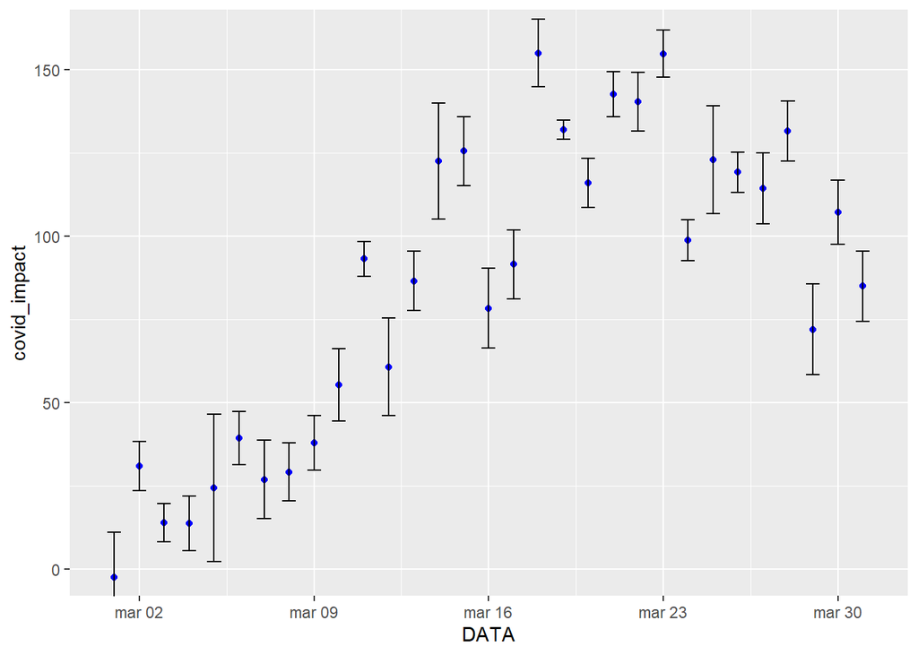

```r
ggplot(emilia,aes(x=DATA,y=covid_impact))+
  geom_point(col='blue')+
  coord_cartesian( ylim = c(0, 160))+
  geom_errorbar(aes(ymin=covid_impact-sd_decessi, ymax=covid_impact+sd_decessi), width=.55)
```